# R Notebook

```r
biocLite("plyr")
biocLite("dplyr")
library("plyr")
library("dplyr")
```

```r
test <- cor(BRCA_mRNA[1,], as.numeric(BRCA_pheno$days[BRCA_mRNA_patients$patient_id]))

test2 <- apply(BRCA_mRNA, 1, cor, y = as.numeric(BRCA_pheno$days[BRCA_mRNA_patients$patient_id]))
plot(test2, cex = 0.1)

# gives indices:
ordered <- order(test2, decreasing = TRUE)

res <- apply(
  BRCA_mRNA,
  2,
  function(x){
    return(
      mean(x[ordered[(0.5*length(ordered):length(ordered))]])
      )
    }
  )
plot(res, cex = 0.1, col = ifelse(as.numeric(BRCA_pheno$days[BRCA_mRNA_patients$patient_id]) < 300, "red", "green"))
```

[output not shown]

It doesn’t look very convincing, but that is because the highest correlation is only 0.169. Don’t forget to use training and testing dataset, and cross-validation later on!

```r
test2 <- apply(BRCA_mRNA, 1, cor, y = as.numeric(BRCA_pheno$days[BRCA_mRNA_patients$patient_id]))
plot(test2, cex = 0.1)

# gives indices:
ordered <- order(test2, decreasing = TRUE)

res <- apply(
  BRCA_mRNA,
  2,
  function(x){
    return(
      mean(x[ordered[(0.5*length(ordered):length(ordered))]])
    )
  }
)
plot(res, cex = 0.1, col = ifelse(as.numeric(BRCA_pheno$days[BRCA_mRNA_patients$patient_id]) < 300, "red", "green"))
```

13-03-2017

A lot of times with survival data, instead of what I did, a univariate survival model is used. Read about Cox proportional hazard model. R-function is called coxPH(), package needed is ‘survival’.

[figure not shown]

```r
# biocLite("survival")
library("survival")
surv_obj <- Surv(time = as.numeric(BRCA_pheno$days[BRCA_mRNA_patients$patient_id]), event = !as.logical(BRCA_pheno$censored[BRCA_mRNA_patients$patient_id]), type = "right")

# for 1 gene:
Y <- BRCA_mRNA
test_cox <- coxph(surv_obj ~ Y[1,], data = as.data.frame(Y))
pval <- unlist(summary(test_cox))$logtest.pvalue

pvals_BRCA_mRNA <- apply(
  BRCA_mRNA,
  1,
  function(row){
    return(
      unlist(summary(coxph(surv_obj ~ row)))$logtest.pvalue
    )
  }
)

pval_order <- order(pvals_BRCA_mRNA, decreasing = TRUE)
high_cor_genes <- pval_order[1:ceiling(length(pval_order)/2)]

BRCA_mRNA_highcor <- apply(
  BRCA_mRNA,
  2,
  function(col){
    return(
      mean(col[high_cor_genes])
    )
  }
)

# original code by Ashar:
# pvalue.sig<- c(0)
#
# for ( i in 1:ncol(Y)){
#   q1 <- unlist(summary(coxph(surv.obj ~ Y[,i], data = as.data.frame(Y))))
#   pvalue.sig[i] <- q1$logtest.pvalue
#
# }
plot(BRCA_mRNA_highcor, cex = 0.1, col = ifelse(as.numeric(BRCA_pheno$days[BRCA_mRNA_patients$patient_id]) < 300, "red", "green"))
```

10-04-2017

Idea: keep the pval vector from code above. When going over the pathways, take the average (edit average function for this) from just the highest scoring genes in that pathway. So take all the pathway genes, look up their p-values and take the average from just the top half.

11-04-2017

```r
colnames(test_top50) <- names(kegg2)
```

```
Error in `colnames<-`(`*tmp*`, value = c("04610", "00232", "00983", "01100",  :
  length of 'dimnames' [2] not equal to array extent
```

There’s something wrong with the patient names. In some data sets, they are separated by dashes and in others by dots. I did fix this, but then the server crashed and apparently I didn’t correct it again. I want to correct everything to dots.

The problematic (i.e. having dashes) data sets are: miRNAseq and mRNA for every disease

```r
# test <- unlist(lapply(strsplit(colnames(BRCA_mRNA), split = "[-]"), vpaste0, collapse = "."))
for(d in names(diseases)){
  for(o in c("miRNAseq", "mRNA")){
    objname <- sprintf("%s_%s", d, o)
    if(exists(objname)){
      obj <- get(objname)
      colnames(obj) <- unlist(lapply(strsplit(colnames(obj), split = "[-]"), vpaste0, collapse = "."))
      assign(objname, obj)
    }
  }
}
```

```r
for(d in names(diseases)){
  for(o in c("miRNAseq", "mRNA")){
    objname <- sprintf("%s_%s", d, o)
    if(exists(objname)){
      obj <- get(objname)
      assign(sprintf("%s_patients", objname),
             GetPatientsVec(colnames(obj), save = FALSE)
      )
    }
  }
}
```

It seems to work for BRCA_mRNA, let’s see it for the other omics data types:

```r
for(d in names(diseases)){
  print(d)
  pheno <- get(sprintf("%s_pheno", d))
  for(o in omics){
    print(o)
    objname <- sprintf("%s_%s", d, o)
    if(exists(objname)){
      obj <- get(objname)
      patients <- get(sprintf("%s_patients", objname))
      surv_obj <- Surv(time = as.numeric(pheno[patients$patient_id, 'days']), event = !as.logical(pheno[patients$patient_id, 'censored']), type = "right")

      pval <- apply(
        obj,
        1,
        function(row){
          return(
            unlist(summary(coxph(surv_obj ~ row)))$logtest.pvalue
          )
        }
      )

      res <- AveragePerPathway(1:229, d, o, top50 = TRUE, pval = pval)
      colnames(res) <- names(kegg2)
      assign(sprintf("%s_top50pw", objname), res)
    }
  }
}
```

```
[1] "BRCA"
[1] "mRNA"
[1] "mRNAseq"
```

[output not shown]

19-04-2017

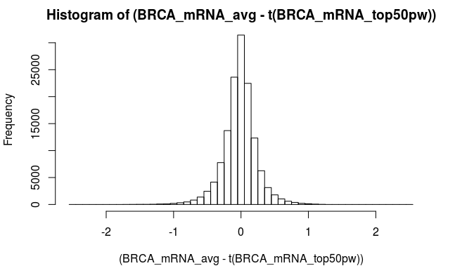

```r
hist((BRCA_mRNA_avg - t(BRCA_mRNA_top50pw)), breaks = c(seq(from = -2.55, to = 2.55, by = 0.1)))
```